# Understanding college debt

I want to see what types of universities have students in debt. We will be using the college scorecard API from data.gov. I am interested in a number of variables, these are admissions rate, tuition, median household income, student size, etc.

It seems that the UC office of president [claims that the UC schools are a good deal](http://www.ucop.edu/institutional-research-academic-planning/_files/College%20Scorecard%20Brief.pdf) based on data from the college scorecard.

You should go begin by getting an [API key for data.gov](https://api.data.gov/signup/). There are many data.gov APIs that you can use this key for and they have fairly relaxed limits on the number of requests.

The documentation for the API can be found here...  
https://github.com/RTICWDT/open-data-maker/blob/master/API.md  
https://collegescorecard.ed.gov/data/

Let's import some packages.

```python
from urllib2 import Request, urlopen
import pandas as pd
import json
from matplotlib import pyplot as plt
plt.style.use('ggplot')
%matplotlib inline
```

Here are some variable names that we will be interested in.

```python
varnames = """id
school.name
school.degrees_awarded.predominant
2014.admissions.admission_rate.overall
2014.cost.tuition.in_state
2014.cost.tuition.out_of_state
2014.aid.median_debt.completers.overall
2014.aid.median_debt.noncompleters
2005.student.demographics.median_hh_income
2005.student.demographics.poverty_rate
2014.aid.federal_loan_rate
2014.aid.pell_grant_rate
2014.student.size"""
```

**Exercise (1)** I would like to make a complicated query from the API. An example query from the API is

```
https://api.data.gov/ed/collegescorecard/v1/schools.json?school.degrees_awarded.predominant=3&_fields=school.name,
2014.aid.pell_grant_rate&_sort=2014.student.size:desc&_page=1
&_per_page=100&api_key=YOURKEY
```

Which can be parsed as

1. the base url: https://api.data.gov/ed/collegescorecard/v1/schools.json,
2. a filter of school.degrees_awarded.predominant=3,
3. return the fields school.name,2014.aid.pell_grant_rate,
4. sort by 2014.student.size in descending order,
5. return 1 page of 100 entries,
6. and use your api key

You can find a more complete description: https://github.com/RTICWDT/open-data-maker/blob/master/API.md

Fill in the following def that fits the following docstring, and gives the shown output.

```
def query_url(key,fieldnames,filterstring,sortvar,numpages):
    """
    This takes all of the necessary parameters to form a query
    to college scorecard
    Input: key (data.gov API key, string), fieldnames (list of variable
      names), filterstring (string for filtering), sortvar (variable to
      sort with by descending), numpages (number of pages to return)
    Output: url (string)
    """


query_url(key,fieldnames,'school.degrees_awarded.predominant=3',
  '2014.student.size',2)

https://api.data.gov/ed/collegescorecard/v1/schools.json?school.degrees_awarded.predominant=3&_fields=id,school.name,school.degrees_awarded.predominant,school.degree_urbanization,2014.admissions.admission_rate.overall,2014.cost.tuition.in_state,2014.cost.tuition.out_of_state,2014.aid.median_debt.completers.overall,2014.aid.median_debt.noncompleters,2005.student.demographics.median_hh_income,2005.student.demographics.poverty_rate,2014.aid.federal_loan_rate,2014.aid.pell_grant_rate,2014.student.size&_page=2&_per_page=100&_sort=2014.student.size:desc&api_key=YOURKEYHERE
```

Try to reproduce the above behavior.

```python
def query_url(key,fieldnames,filterstring,sortvar,numpages):
    """
    This takes all of the necessary parameters to form a query
    to college scorecard
    Input: key (data.gov API key, string), fieldnames (list of variable
      names), filterstring (string for filtering), sortvar (variable to
      sort with by descending), numpages (number of pages to return)
    Output: url (string)
    """
    base_url = 'https://api.data.gov/ed/collegescorecard/v1/schools.json'
    fnames = ','.join(e for e in fieldnames) #join fieldnames list, separated bt comma
    sym = ['?', '&_fields=', '&_page=', '&_per_page=100', '&_sort=', ':desc&api_key='] #list of various symbols
    #forming the final url piece by piece, adding the necessary syntaxical elements.
    url = (base_url + sym[0] + filterstring + sym[1] + fnames + sym[2] + str(numpages) + sym[3] + sym[4] +
    sortvar + sym[5] + key)
    return url

fieldnames = varnames.split('\n') #using the given varnames
fieldnames.insert(3, 'school.degree_urbanization') #add in the urbanization var. name to match given output
key = '5GHpLQmI9O0B2Eo4kPtQhHJmW6Lqq8BIursHxlWq' #api key

print query_url(key,fieldnames,'school.degrees_awarded.predominant=3',
  '2014.student.size',2)
```

[output not shown]

**Exercise (2)** Make the query using Request and load the results into a DataFrame that makes sense.

```python
debt_df = pd.DataFrame(res['results']) #converting to pandas df
debt_df = debt_df.reindex_axis(fieldnames, axis = 1) #reorder to match fieldnames
debt_df
```

[output not shown]

**Exercise (3)** Produce scatterplots to demonstrate the associations between student debt (for 'completers') and median household income, pell grant rates, student poverty rate, tuition, and federal loan rate. Do you have an explanation for the associations that you are seeing? Are there some surprising associations.

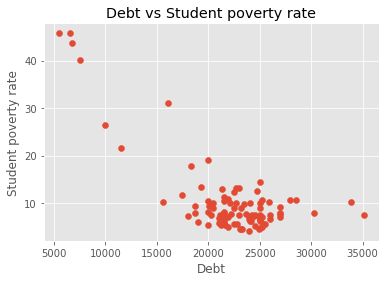

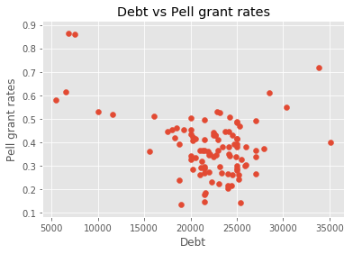

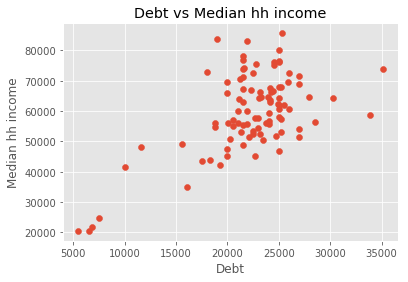

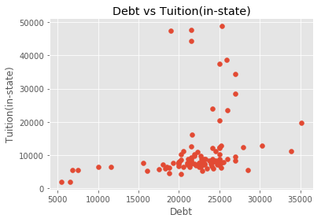

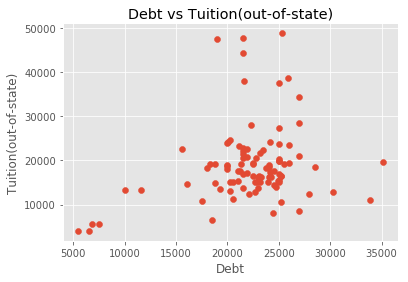

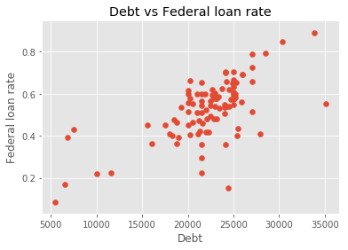

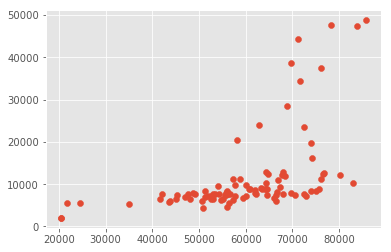

```python
debt = debt_df.iloc[:,7] #extracting debt(completers) with .iloc
#dictionary with var. names as keys and their corresponding numeric index as values
var_dict = {'Median hh income':9, 'Pell grant rates':12, 'Student poverty rate':10, 'Tuition(in-state)':5,
             'Tuition(out-of-state)':6, 'Federal loan rate':11}
for key, val in var_dict.iteritems(): #loop to plot all the vars. against debt
    plt.scatter(debt, debt_df.iloc[:,val],)
    plt.xlabel('Debt')
    plt.ylabel(key)
    plt.title('Debt vs ' + key)
    plt.show()
plt.scatter(debt_df.iloc[:,9], debt_df.iloc[:,5]) #check med. hh income vs. tuition(in-state)
```

It seems that for the most part we are seeing that debt amounts are heavily concentrating around the 17,000 to 27,000 range and with a few to either extremes of the debt spectrum. This is evident in all of the scatter plots. Perhaps, this is an amount deemed reasonable or acceptable to the general student population across these different universities. Otherwise, most of the associations seems to be as expected. For example, median household income and federal loan rate tend to trend upward with increasing debt. Both types of tuitions, on the other hand, exhibit suprising associations with debt. For both, the distribution look quite strange, not adhereing to any obvious patterns. It is also far from obvious or clear that as tuition goes up, debt goes up with it. The highest tuitions are probably private univsersities where, perhaps, the type of students who goes there can afford it while maintaining the same, mid-range amount of debt. Plotting median household income vs. in-state tution reveals that for higher end tutions universities, median household income is also at the upper end.